# Modul 2 - Analisis Deskriptif

2024-09-27

# Modul 2 - Analisis Deskriptif

## Objektif Praktikum

1. Praktikan mampu memahami analisis desktriptif
2. Praktikan mampu melakukan analisis deskriptif

## Review Teori

Secara umum, statistik deskriptif bertujuan untuk mereduksi data sehingga dengan penampilan yang lebih sederhana dapat mendeskripsikan karakteristik data.

## Analisis Deskriptif

Analisis deskriptif adalah suatu cara menggambarkan persoalan berdasarkan data yang dimiliki, yakni dengan cara menata data tersebut sedemikian rupa sehingga dengan mudah dapat dipahami karakteristiknya, dapat dijelaskan dan digunakan untuk keperluan selanjutnya melalui sebuah proses reduksi data. Reduksi data merupakan metode untuk meringkas sekumpulan data ke dalam kumpulan data yang lebih kecil yang menggambarkan pengamatan awal tanpa mengorbankan informasi penting. Analisis statistik deskriptif lebih berhubungan dengan kegiatan pengumpulan, peringkasan, dan penyajian data. Analisis ini melibatkan penggunaan sejumlah kecil angka, tabel, dan grafik untuk menyimpulkan sederet angka yang lebih besar. Secara umum, metode reduksi data dibagi menjadi tiga, yaitu:

### Reduksi Data Dasar

Reduksi data dasar membantu menunjukkan distribusi data secara menyeluruh dan cepat. Reduksi data dasar terbagi menjadi tiga jenis, yaitu:

- Reduksi Data dalam Nilai Baku

  Reduksi data dengan cara membuat perbandingan antara jumlah kejadian dalam suatu kategori terhadap jumlah kejadian pada kategori lain maupun keseluruhan, baik yang nyata maupun yang potensial terjadi. Bentuk reduksi data dalam nilai baku adalah proporsi, prosentase, rates, dan rasio.
- Reduksi Data dalam Tabel

  Reduksi data dalam bentuk tabel distribusi frekuensi, yaitu tabel yang meringkas distribusi nilai variabel dengan menunjukkan jumlah kejadian pada setiap kategori nilai variabel.
- Reduksi Data dalam Chart/Grafik

  yaitu reduksi data dalam bentuk gambar yang dapat menunjukkan chart/grafik yang bermacam-macam sesuai kebutuhan. Namun, chart/grafik yang paling umum digunakan adalah pie chart yang menggunakan permukaan lingkaran untuk menggambarkan distribusi proporsi antar kategori, bar chart yang menggunakan balok untuk menggambarkan distribusi proporsi, histogram yang menggunakan balok untuk menggambarkan distribusi frekuensi data interval rasio, dan frequency polygons yang menggunakan titik untuk menggambarkan distribusi frekuensi data interval rasio.

Secara ringkas, reduksi data dapat dilihat pada tabel di bawah berdasarkan tipe datanya

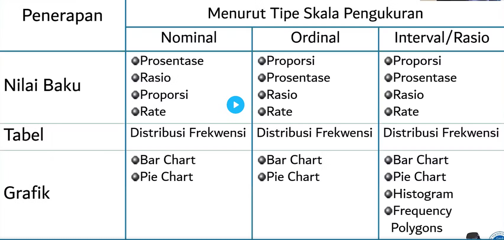

### Ukuran Kecenderungan Memusat

Ukuran kecenderungan memusat merupakan ukuran yang menunjukkan pada nilai variabel mana kejadian cenderung terkonsentrasi. Ukuran kecenderungan memusat yang digunakan ada tiga yaitu:

- Modus

  Modus adalah nilai yang paling banyak muncul. Modus digunakan sebagai tipe skala pengukuran kecenderungan memusat pada **data nominal**.
- Median

  Median adalah nilai variabel dari objek yang mempunyai setengah jumlah objek di atasnya dan setengah jumlah objek di bawahnya setelah semua nilai variabel objek diurutkan dari yang terkecil sampai yang terbesar. Median digunakan sebagai tipe skala pengukuran kecenderungan memusat pada **data ordinal**.
- Mean

  Mean adalah nilai rata-rata dari suatu variabel. rata-rata tersebut dihitung dengan menjumlahkan seluruh nilai pada suatu variabel dan membaginya dengan jumlah data yang ada. Mean umum digunakan untuk melihat kecenderungan memusat pada data **interval rasio**

### Ukuran Persebaran Data

Ukuran persebaran data adalah suatu ukuran yang memberikan suatu indikasi tingkat heterogenitas atau keragaman dalam distribusi nilai variabel. Terdapat tiga skala pengukuran yang digunakan sebagai ukuran persebaran data yaitu:

- Indeks Variansi Kualitatif

  Indeks variansi kualitatif adalah rasio jumlah variasi yang diamati secara nyata dalam suatu distribusi nilai pada variasi maksimum yang dapat terjadi dalam distribusi tersebut. IQV kerap digunakan untuk melihat persebaran data pada data nominal. Indeks variansi kualitatif (IQV) dapat dihitung menggunakan rumus:

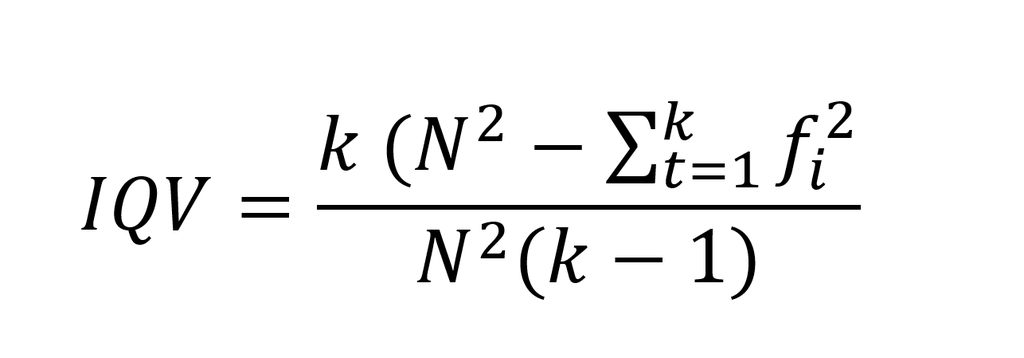

  dengan:

  *k =* jumlah kategori

  N = jumlah kasus/objek

  i = jumlah kasus/objek dalam kategori i

  IQV = 0 berarti bahwa tingkat heterogenitas rendah atau dapat dikatakan seragam

  IQV = 1 berarti bahwa tingkat heterogenitas tinggi
- Rentang

  Rentang merupakan selisih nilai variabel objek yang terbesar dan yang terkecil. Rentang digunakan untuk melihat persebaran data pada data ordinal.
- Variansi dan Standar Deviasi/Simpangan Baku

  Variansi adalah nilai rata-rata kuadrat selisih nilai variabel setiap objek dengan nilai rata-rata variabel. Variansi dan standar deviasi digunakan untuk melihat persebaran data pada interval rasio. Nilai standar deviasi terkecil adalah 0 dimana semakin besar nilai variansi dan standar deviasi maka data makin bervariasi. Variansi dan standar deviasi dapat dihitung dengan rumus:

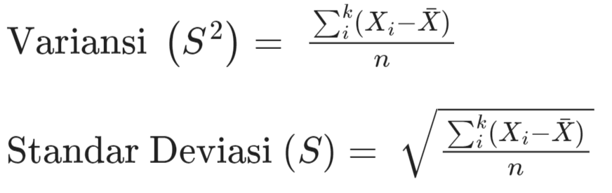

  Dengan:

  N = jumlah data

  Xi = data ke-i

  X bar = rata-rata sampel/populasi

## Hands-on Praktikum

### Review Data

Dalam praktikum ini terdapat 2 data csv yang akan digunakan untuk melatih analisis deskriptif. Kedua data tersebut merupakan bagian dari data kuesioner ojek online yang dilakukan pada tahun 2023. Adapun rincian variabel pada setiap data antara lain

- Data 1
  - id_driver
  - preferensi_merchant
  - preferensi_transportasi
  - usia
  - status_nikah
  - jml_motor
  - jml_mobil
  - jml_sepeda

  ```r
  data1 <- read.csv("data/data_1.csv")
  ```

- Data 2
  - id
  - peta_acuan
  - pr_permukiman
  - pr_perkantoran
  - pr_pendidikan
  - pr_ofm (merchant makanan minuman)
  - pr_transport_umum
  - pr_taman
  - pr_hotel
  - pr_pasar_mall
  - pr_kesehatan
  - usia
  - jenis kelamin
  - status_menikah
  - pendidikan
  - jml_motor
  - jml_mobil
  - jml_sepeda

  ```r
  data2 <- read.csv("data/data_2.csv")
  ```

### Reduksi Tabel

Dalam melakukan reduksi tabel, data yang dipakai merupakan `data_2`

- minimum, maximum, dan range pada variabel usia

  ```r
  min(data2$usia)
  ```

  ```
  ## [1] 16
  ```

  ```r
  max(data2$usia)
  ```

  ```
  ## [1] 558
  ```

  ```r
  range(data2$usia)
  ```

  ```
  ## [1]  16 558
  ```

  ```r
  max(data2$usia) - min(data2$usia)
  ```

  ```
  ## [1] 542
  ```

  untuk menyimpan hasil range dapat dilakukan dengan cara berikut

  ```r
  range_data2 <- max(data2$usia) - min(data2$usia)
  range_data2
  ```

  ```
  ## [1] 542
  ```

  maka variabel range_data2 akan otomatis tersimpan dan muncul pada tab environment
- Mean, Median, Modus

  ```r
  mean(data2$usia)
  ```

  ```
  ## [1] 38.92573
  ```

  ```r
  median(data2$jml_anggota_rt)
  ```

  ```
  ## [1] 4
  ```

  ```r
  #membuat function untuk mengidentifikasi setiap nilai unik pada data2
  mode_data2 <- function(data2) {
     uniq_data2 <- unique(data2)
     uniq_data2[which.max(tabulate(match(data2, uniq_data2)))]
  }

  #melihat modus pada variabel posisi rumah tangga
  mode_data2(data2$posisi_rt)
  ```

  ```
  ## [1] "Kepala rumah tangga"
  ```

  ```r
  #melihat modus pada variabel pekerjaan selain ojek online
  mode_data2(data2$pekerjaan_selain)
  ```

  ```
  ## [1] "Tidak ada"
  ```

  Fungsi `mode_data2`dalam R digunakan untuk menghitung modus, yang merupakan nilai yang paling sering muncul dalam kumpulan data tertentu. Pertama, fungsi ini mengidentifikasi semua nilai unik dalam vektor pada `data2`menggunakan `unique()`fungsi tersebut. Kemudian, fungsi `match()` digunakan untuk memetakan setiap nilai dalam vektor asli ke nilai uniknya yang sesuai dan digunakan `tabulate()`untuk menghitung frekuensi setiap nilai unik. Terakhir, `which.max()`fungsi ini digunakan untuk mengidentifikasi indeks frekuensi tertinggi, dan fungsi ini mengembalikan nilai unik pada indeks tersebut sebagai modus. Intinya, fungsi ini digunakan untuk menghitung kemunculan setiap nilai dan mengembalikan nilai yang paling sering muncul.
- Standar deviasi dan varians

  ```r
  sd(data2$usia)
  ```

  ```
  ## [1] 23.80936
  ```

  ```r
  var(data2$usia)
  ```

  ```
  ## [1] 566.8855
  ```

- Melihat summary

  summary dilakukan sama seperti pada praktikum sebelumnya

  ```r
  #melihat summary pada variabel usia
  summary(data2$usia)
  ```

  ```
  ##    Min. 1st Qu.  Median    Mean 3rd Qu.    Max.
  ##   16.00   30.00   37.00   38.93   45.00  558.00
  ```

  ```r
  #melihat summary usia berdasarkan grouping tingkat pendidikan
  by(data2$usia, data2$pendidikan, summary)
  ```

  ```
  ## data2$pendidikan: D3
  ##    Min. 1st Qu.  Median    Mean 3rd Qu.    Max.
  ##      25      25      25      25      25      25
  ## ------------------------------------------------------------
  ## data2$pendidikan: Diploma
  ##    Min. 1st Qu.  Median    Mean 3rd Qu.    Max.
  ##   20.00   35.25   40.50   41.11   48.50   74.00
  ## ------------------------------------------------------------
  ## data2$pendidikan: Pascasarjana atau lebih tinggi
  ##    Min. 1st Qu.  Median    Mean 3rd Qu.    Max.
  ##      42      42      42      42      42      42
  ## ------------------------------------------------------------
  ## data2$pendidikan: Sarjana
  ##    Min. 1st Qu.  Median    Mean 3rd Qu.    Max.
  ##   21.00   31.00   37.00   39.42   47.00   63.00
  ## ------------------------------------------------------------
  ## data2$pendidikan: SD
  ##    Min. 1st Qu.  Median    Mean 3rd Qu.    Max.
  ##   23.00   40.00   45.00   60.28   49.75  558.00
  ## ------------------------------------------------------------
  ## data2$pendidikan: SMA/SMK
  ##    Min. 1st Qu.  Median    Mean 3rd Qu.    Max.
  ##   16.00   30.00   35.00   36.85   43.00   68.00
  ## ------------------------------------------------------------
  ## data2$pendidikan: SMP
  ##    Min. 1st Qu.  Median    Mean 3rd Qu.    Max.
  ##   24.00   31.00   38.00   39.19   44.50   70.00
  ## ------------------------------------------------------------
  ## data2$pendidikan: STM
  ##    Min. 1st Qu.  Median    Mean 3rd Qu.    Max.
  ##      35      35      35      35      35      35
  ## ------------------------------------------------------------
  ## data2$pendidikan: Tidak ada
  ##    Min. 1st Qu.  Median    Mean 3rd Qu.    Max.
  ##      45      45      45      45      45      45
  ```

- melihat summary descriptive statistics lain menggunakan pastecs

  ```r
  install.packages("pastecs")
  ```

  ```r
  library(pastecs)
  stat.desc(data2)
  ```

  ```
  ##                        id   peta_acuan pr_permukiman pr_perkantoan
  ## nbr.val      5.790000e+02 5.790000e+02            NA            NA
  ## nbr.null     0.000000e+00 0.000000e+00            NA            NA
  ## nbr.na       0.000000e+00 0.000000e+00            NA            NA
  ## min          1.000000e+00 1.000000e+00            NA            NA
  ## max          5.790000e+02 5.000000e+00            NA            NA
  ## range        5.780000e+02 4.000000e+00            NA            NA
  ## sum          1.679100e+05 1.989000e+03            NA            NA
  ## median       2.900000e+02 4.000000e+00            NA            NA
  ## mean         2.900000e+02 3.435233e+00            NA            NA
  ## SE.mean      6.952218e+00 5.105462e-02            NA            NA
  ## CI.mean.0.95 1.365469e+01 1.002752e-01            NA            NA
  ## var          2.798500e+04 1.509206e+00            NA            NA
  ## std.dev      1.672872e+02 1.228498e+00            NA            NA
  ## coef.var     5.768523e-01 3.576169e-01            NA            NA
  ##              pr_pendidikan pr_ofm pr_transport_umum pr_taman pr_hotel
  ## nbr.val                 NA     NA                NA       NA       NA
  ## nbr.null                NA     NA                NA       NA       NA
  ## nbr.na                  NA     NA                NA       NA       NA
  ## min                     NA     NA                NA       NA       NA
  ## max                     NA     NA                NA       NA       NA
  ## range                   NA     NA                NA       NA       NA
  ## sum                     NA     NA                NA       NA       NA
  ## median                  NA     NA                NA       NA       NA
  ## mean                    NA     NA                NA       NA       NA
  ## SE.mean                 NA     NA                NA       NA       NA
  ## CI.mean.0.95            NA     NA                NA       NA       NA
  ## var                     NA     NA                NA       NA       NA
  ## std.dev                 NA     NA                NA       NA       NA
  ## coef.var                NA     NA                NA       NA       NA
  ##              pr_pasar_mall pr_kesehatan         usia jk status_menikah
  ## nbr.val                 NA           NA 5.790000e+02 NA             NA
  ## nbr.null                NA           NA 0.000000e+00 NA             NA
  ## nbr.na                  NA           NA 0.000000e+00 NA             NA
  ## min                     NA           NA 1.600000e+01 NA             NA
  ## max                     NA           NA 5.580000e+02 NA             NA
  ## range                   NA           NA 5.420000e+02 NA             NA
  ## sum                     NA           NA 2.253800e+04 NA             NA
  ## median                  NA           NA 3.700000e+01 NA             NA
  ## mean                    NA           NA 3.892573e+01 NA             NA
  ```

  [output cut: 50 more lines]

  ```
  ##              status_kepemilikan lama_driver ojek_konvensional
  ## nbr.val                      NA          NA                NA
  ## nbr.null                     NA          NA                NA
  ## nbr.na                       NA          NA                NA
  ## min                          NA          NA                NA
  ## max                          NA          NA                NA
  ## range                        NA          NA                NA
  ## sum                          NA          NA                NA
  ## median                       NA          NA                NA
  ## mean                         NA          NA                NA
  ## SE.mean                      NA          NA                NA
  ## CI.mean.0.95                 NA          NA                NA
  ## var                          NA          NA                NA
  ## std.dev                      NA          NA                NA
  ## coef.var                     NA          NA                NA
  ```

  ```r
  #syntax hanya berlaku pada variabel numerik
  ```

- Melakukan crosstab menggunakan ctable

  crosstab digunakan untuk melihat perbandingan dan persebaran antara dua variabel secara bersilangan

  ```r
  install.packages("summarytools")
  ```

  ```r
  library(summarytools)
  ctable(
    x = data2$pendidikan,
    y = data2$status_menikah
  )
  ```

  ```
  ## Cross-Tabulation, Row Proportions
  ## pendidikan * status_menikah
  ## Data Frame: data2
  ##
  ## -------------------------------- ---------------- --------------- ----------- ------------ ---------- -------------- --------------
  ##                                    status_menikah   Belum Menikah       Cerai   Cerai mati       Duda        Menikah          Total
  ##                       pendidikan
  ##                               D3                       1 (100.0%)    0 (0.0%)     0 (0.0%)   0 (0.0%)     0 (  0.0%)     1 (100.0%)
  ##                          Diploma                       6 ( 16.7%)    2 (5.6%)     0 (0.0%)   0 (0.0%)    28 ( 77.8%)    36 (100.0%)
  ##   Pascasarjana atau lebih tinggi                       0 (  0.0%)    0 (0.0%)     0 (0.0%)   0 (0.0%)     1 (100.0%)     1 (100.0%)
  ##                          Sarjana                       6 ( 13.3%)    1 (2.2%)     0 (0.0%)   0 (0.0%)    38 ( 84.4%)    45 (100.0%)
  ##                               SD                       1 (  3.1%)    0 (0.0%)     1 (3.1%)   1 (3.1%)    29 ( 90.6%)    32 (100.0%)
  ##                          SMA/SMK                      61 ( 15.9%)   11 (2.9%)     0 (0.0%)   0 (0.0%)   311 ( 81.2%)   383 (100.0%)
  ##                              SMP                       9 ( 11.4%)    2 (2.5%)     0 (0.0%)   0 (0.0%)    68 ( 86.1%)    79 (100.0%)
  ##                              STM                       0 (  0.0%)    0 (0.0%)     0 (0.0%)   0 (0.0%)     1 (100.0%)     1 (100.0%)
  ##                        Tidak ada                       0 (  0.0%)    0 (0.0%)     0 (0.0%)   0 (0.0%)     1 (100.0%)     1 (100.0%)
  ##                            Total                      84 ( 14.5%)   16 (2.8%)     1 (0.2%)   1 (0.2%)   477 ( 82.4%)   579 (100.0%)
  ## -------------------------------- ---------------- --------------- ----------- ------------ ---------- -------------- --------------
  ```

### Reduksi Grafik

Pada praktikum sebelumnya telah dijelaskan mengenai cara mereduksi data menggunakan grafik histogram dan scatter plot. Berikut merupakan beberapa grafik yang dapat digunakan untuk melakukan reduksi data.

- Boxplot

  boxplot lazim digunakan untuk melihat persebaran/distribusi dari sebuah data. Boxplot secara grafis menggambarkan distribusi variabel kuantitatif dengan menampilkan beberapa lokasi distribusi data (minimum, median, kuartil pertama/ketiga, dan maksimum) dan setiap observasi yang diklasifikasikan sebagai outlier yang diduga menggunakan kriteria rentang interkuartil (IQR).

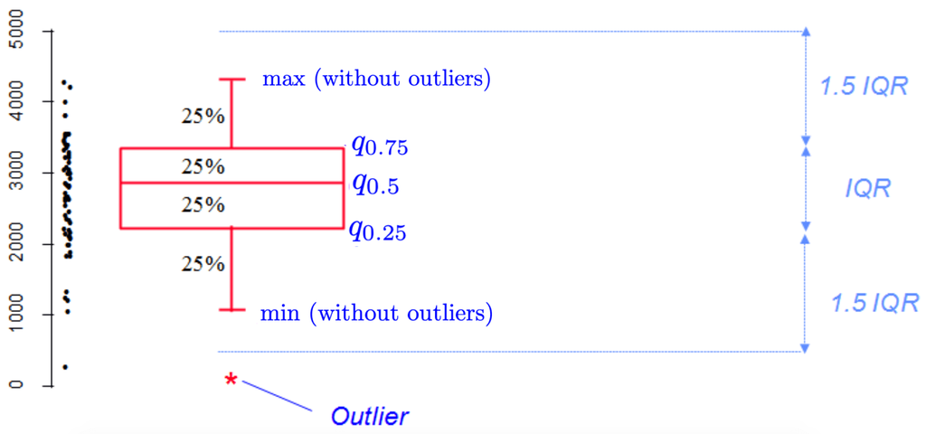

  sumber gambar : LFSAB1105

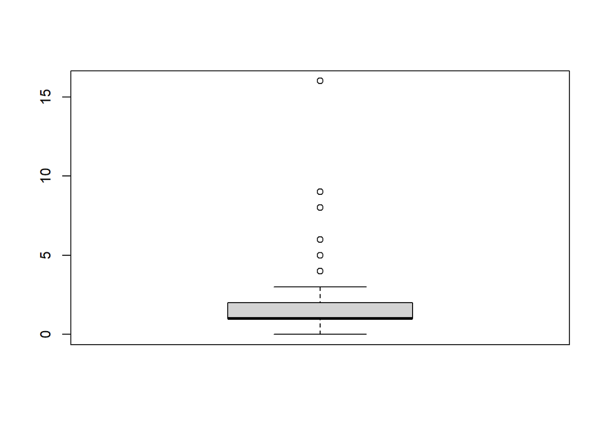

  ```r
  boxplot(data2$jml_kendaraan_pribadi)
  ```

  boxplot juga dapat digunakan untuk membandingkan beberapa variabel untuk dilihat persebaran masing-masing datanya

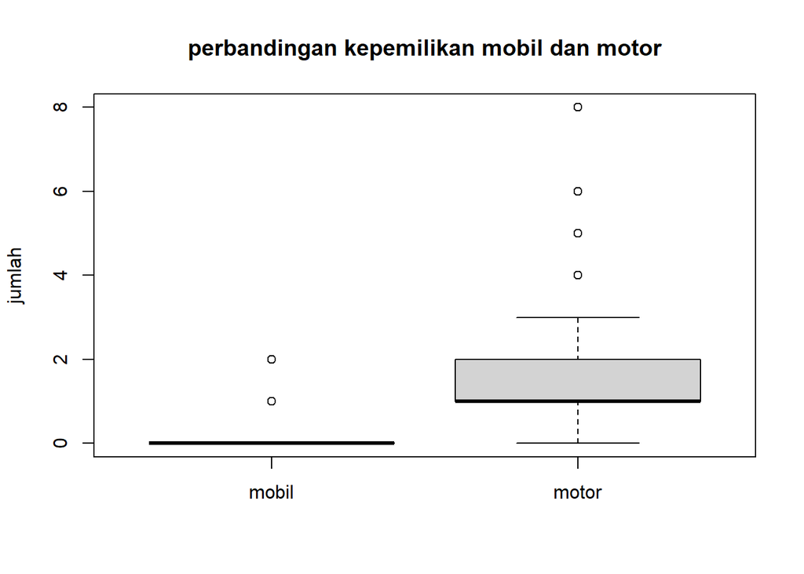

  ```r
  #membandingkan kepemilikan mobil dan motor
  jml_mobil <- data2$jml_mobil
  jml_motor <- data2$jml_motor
  jml_sepeda <- data2$jml_sepeda
  boxplot(jml_mobil,jml_motor,
          main = "perbandingan kepemilikan mobil dan motor",
          ylab = "jumlah",
          names = c("mobil","motor"))
  ```

- pie chart

  pie chart biasa digunakan untuk melihat persentase untuk suatu variabel

  ```r
  #install ggplot2 terlebih dahulu
  install.packages("ggplot2")
  ```

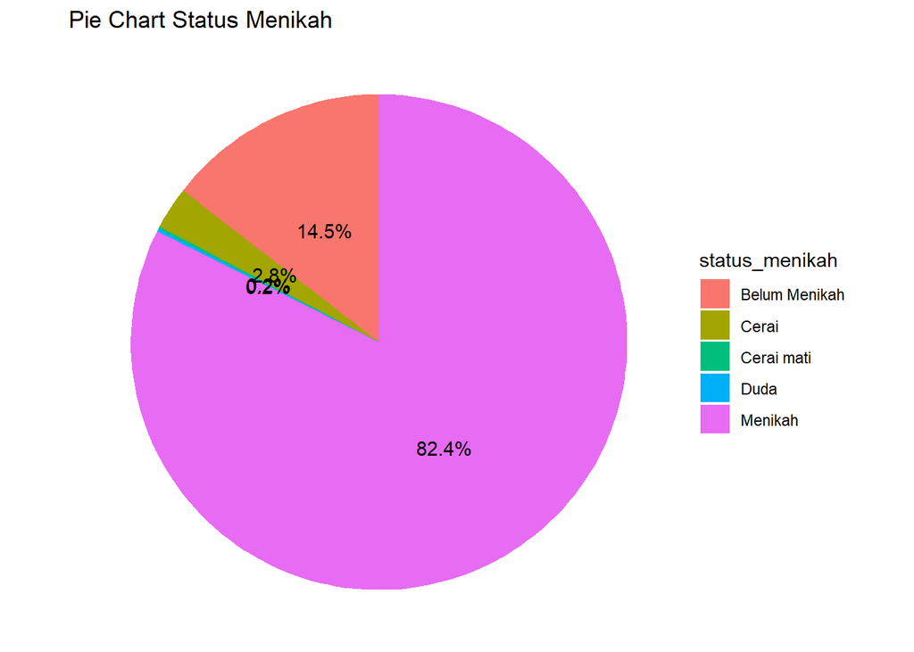

  ```r
  library(ggplot2)
  library(dplyr)
  data2_summary <- data2 %>%
    group_by(`status_menikah`) %>%
    summarise(count = n()) %>%
    mutate(percentage = round(count / sum(count) * 100, 1))  #menghitung persentase

  ggplot(data2_summary, aes(x = "", y = count, fill = `status_menikah`)) +
    geom_bar(stat = "identity", width = 1) +
    coord_polar(theta = "y") +
    geom_text(aes(label = paste0(percentage, "%")),
              position = position_stack(vjust = 0.5)) +  # menambah label persentase
    labs(title = "Pie Chart Status Menikah") +
    theme_void() +  # Remove background dan axis labels
    theme(legend.position = "right")
  ```

- Bar Chart untuk data categorical

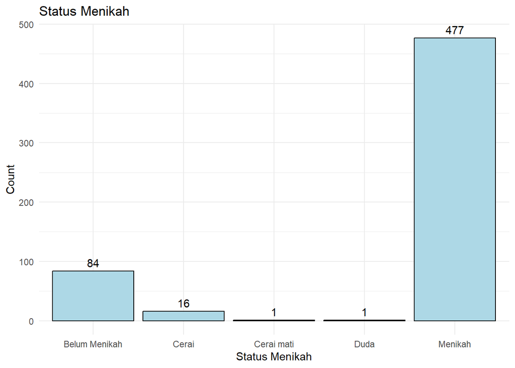

  ```r
  library(ggplot2)
  library(dplyr)

  ggplot(data2, aes(x = `status_menikah`)) +
    geom_bar(fill = "lightblue", color = "black") +
    geom_text(stat = "count", aes(label = ..count..), vjust = -0.5) +  # Menambahkan count labels
    labs(title = "Status Menikah", x = "Status Menikah", y = "Count") +
    theme_minimal()
  ```

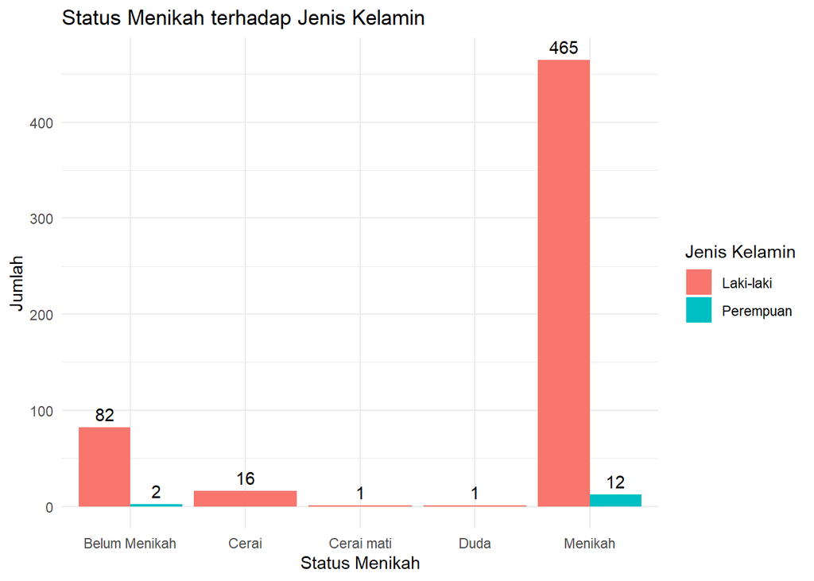

  ```r
  ggplot(data2, aes(x = `status_menikah`, fill = `jk`)) +
    geom_bar(position = "dodge") +  # menggunakan posisi "dodge" untuk membuat bar side by side
    geom_text(stat = "count", aes(label = ..count..), position = position_dodge(width = 0.9), vjust = -0.5) +
    labs(title = "Status Menikah terhadap Jenis Kelamin",
         x = "Status Menikah",
         y = "Jumlah",
         fill = "Jenis Kelamin") +  # menambahkan judul legend
    theme_minimal()  # menggunakan tema minimal
  ```